# Regridding acoustic data following spatial autocorrelation analysis

This code was written by II for the manuscript: https://doi.org/10.1093/icesjms/fsae129 This code is preceded by “Spatial autocorrelation.Rmd” and followed by “Analysis 1.Rmd”

# Objective of code:

Regrid our acoustics data from continuous tracks (gridded in echoview to 100 m horizontal by 5 m vertical grid cells) to spatially independent grid cell size (25 km)

# Background:

Because our data were collected continuously while underway at sea, and because marine organisms are often grouped in space and time according to ecological drivers, there is some spatial autocorrelation present in our data. This poses a challenge in subsequent statistical analysis, as our samples may not be considered independent (a violates of assumptions).

In Spatial autocorrelation.Rmd we created correlograms with our mesopelagic depth integrated values (echo_integration) of 100m horizontal cells (<25 missing vertical cells) and found mean spatial independence at approximately ~25km.

From the spatial autocorrelation analysis, a grid size of 25km would be appropriate for acoustic track data (in other words, at 25km, we should no longer have strong spatial autocorrelation in our data and our observations should represent a spatially independent sample).

# Load libraries

```r
library(sf) # dealing with spatial data
library(raster) # regridding
library(tidyverse)#data wrangle and plotting
```

# Add columns to output df for calculating acoustic metrics

Because we are using the df: output which is our raw 100m by 5m vertical grid data output from echoview, we need to calculate acoustic metrics from these data (instead of calculating the mean of means). To calculate the MVBS we need the linear mean of Sv (sv) (so convert from Sv (log scale) to sv (linear) and take mean and then re-convert) using the following conversions: #Sv to sv: Sv_to_sv <- function(Sv){10^(sv/10)} #sv to Sv: sv_to_Sv <- function(sv){10*log10(sv)}

# Add columns for calculating acoustic metrics

We only want to run this code at the outset of analysis, no need to run for each grid cell size, so added eval=FALSE

```r
# add columns for enabling calculation of acoustic metrics
output <- output |>
          mutate(MVBS_linear= 10^(Sv_mean/10)) |>  #convert Sv to sv (log to linear scale)
          mutate(sv_z=MVBS_linear*Depth_mean) |> # create col for sv * depth (for calculating CM)
          mutate(sv_cellht=MVBS_linear*5) #create additional column for sv * cell height (for calculating NASC)
```

NOTE: because we are now calculating these acoustic metrics over a much bigger region (instead of individual 100m column of water, 1km, 5km etc) I am no longer going to select for those columns with less than 25 cells missing. However, we will check that there were at least 3, 100 m cells present (and count the total number of vertical cells as <25 missing)

# Create grid based on acoustic data extent (specific grid size)

Use the output df (100m by 5m vertical cells) to set the extent and resolution of acoustic data

```r
# create ONE grid for all years- can vary size of grid with dist input
dist= 25000 # this value is in meters (so 5km = 5000m, 25km=25000)

# Convert acoustic data to an sf object------and then convert to projected coordinate system
output_sf <- st_as_sf(x=output, coords=c('Lon_M','Lat_M'), remove = FALSE, crs=4326) #native GCS wgs84
output_sf <- st_transform(output_sf, crs=32610)# Convert to projected coordinate system (UTM Zone 10N, datum: WGS84)
st_crs(output_sf) # check that projected properly

# Create a Raster grid using acoustics extent and set resolution size ------
ext <- raster::extent(output_sf) #lat lon extent
r <- raster::raster(ext=ext, crs=32610) # create a raster feature with the extent of our acoustics data and with our projected coord system UTM Zone 10N
# change the dim of our raster to match dist input (value in meters):
res(r) <- c(dist, dist) # The units of UTM Zone 10N are meters (m) so 25km is 25,000m
```

# Regrid acoustics data to raster grid (of set distance, dist), based on acoustics extent– Calculate MVBS

```r
# create df to store output
acoustics_regrid_utm <- data.frame()

yr= unique(output$year)

for(i in 1:length(yr)){
  #filter for given year
  echo_yr <- output_sf |>
             filter(year==yr[i]) |>
             filter(Layer_depth_min>=175 & Layer_depth_max<=675) #select for meso depths


# rasterize acoustic output (sv mean) to our grid created above with resolution set by (dist=) input
  x_yr<- raster::rasterize(x=echo_yr, y=r, field=echo_yr$MVBS_linear, fun=function(x, ...) c(length(x),mean(x))) # of cells (vertical?) and mean
#convert layer.2 (MVBS) values to dB space (from linear)
  values(x_yr$layer.2) <- 10*log10(values(x_yr$layer.2))

# convert raster output to dataframe object
x_yr_df<- raster::as.data.frame(x=x_yr, xy=TRUE, centroids=TRUE, na.rm=TRUE)
x_yr_df <- x_yr_df |>
  rename(lon=x, lat=y, count=layer.1, MVBS=layer.2) |>  #rename col names
  mutate(year=yr[i]) #add a column with year

# store output in df
acoustics_regrid_utm <- rbind(acoustics_regrid_utm, x_yr_df)
#will reconvert back to WGS 84 in a later step

}

# remove intermediary steps:
rm(echo_yr, x_yr, x_yr_df, i, yr)
```

# Convert output from projected to cooridnate reference system (UTM Zone10N to Lat Lon)

Using output from acoustics_regrid_utm crs=4326

```r
# CONVERT regridded acoustics output from dataframe to SF object, then from UTM Zone 10N back to WGS 84

acoustics_regrid_sf <- st_as_sf(x=acoustics_regrid_utm, coords=c('lon','lat'), remove = FALSE, crs=32610) #since coord currently in UTM zone 10N

acoustics_regrid_sf_wgs <- st_transform(acoustics_regrid_sf, crs=4326)# Convert to projected coordinate system (UTM Zone 10N, datum: WGS84)
st_crs(acoustics_regrid_sf_wgs) # check that projected properly
```

```
Coordinate Reference System:
  User input: EPSG:4326
  wkt:
GEOGCRS["WGS 84",
    ENSEMBLE["World Geodetic System 1984 ensemble",
        MEMBER["World Geodetic System 1984 (Transit)"],
        MEMBER["World Geodetic System 1984 (G730)"],
        MEMBER["World Geodetic System 1984 (G873)"],
        MEMBER["World Geodetic System 1984 (G1150)"],
        MEMBER["World Geodetic System 1984 (G1674)"],
        MEMBER["World Geodetic System 1984 (G1762)"],
        MEMBER["World Geodetic System 1984 (G2139)"],
        ELLIPSOID["WGS 84",6378137,298.257223563,
            LENGTHUNIT["metre",1]],
        ENSEMBLEACCURACY[2.0]],
    PRIMEM["Greenwich",0,
        ANGLEUNIT["degree",0.0174532925199433]],
    CS[ellipsoidal,2],
        AXIS["geodetic latitude (Lat)",north,
            ORDER[1],
            ANGLEUNIT["degree",0.0174532925199433]],
        AXIS["geodetic longitude (Lon)",east,
            ORDER[2],
            ANGLEUNIT["degree",0.0174532925199433]],
    USAGE[
        SCOPE["Horizontal component of 3D system."],
        AREA["World."],
        BBOX[-90,-180,90,180]],
    ID["EPSG",4326]]
```

```r
#col for geometry
acoustics_regrid_sf_wgs <- acoustics_regrid_sf_wgs %>%
          mutate(lon = unlist(map(acoustics_regrid_sf_wgs$geometry,1)), #create col for longitude from old proj
                 lat = unlist(map(acoustics_regrid_sf_wgs$geometry,2))) #c# create separate columns for geometry

#store final output
acoustics_regrid= as.data.frame(acoustics_regrid_sf_wgs) |>
                  dplyr::select(-geometry)

rm(acoustics_regrid_utm) #remove initial output from regrid
```

# Create gridlines based on acoustic regrid output

For selecting by specific grid cell and plotting purposes we need actual values for upper and lower boundaries of each cell We can adjust these to changing distance bins with (dist=) input

```r
# Convert to regular dataframe
acoustics_regrid_utm= st_drop_geometry(acoustics_regrid_sf)
acoustics_regrid_utm= as.data.frame(acoustics_regrid_utm)

# select for unique cells (because some cells are listed multiple times because all 6 years included)

grid= acoustics_regrid_utm |>
      distinct(lat, lon)

grid= grid |>
      mutate(cell=seq(1, nrow(grid), 1))


#save grid values: either side of centroid values
grid= grid |> #this is in the UTM Zone 10N projection
      mutate(lon_grid_low=lon-(dist/2), lat_grid_low=lat-(dist/2)) |>  #new col with centroid value minus half grid cell distance
      mutate(lon_grid_hi=lon+(dist/2), lat_grid_hi=lat+(dist/2))

# HI: convert grid df to sf feature so i can output coordinates -- note have to do this twice because 4 cols and only accepts two?
grid_hi <- grid |>
           dplyr::select(cell, lon_grid_hi, lat_grid_hi)
grid_hi_sf<- sf::st_as_sf(x=grid_hi, coords=c('lon_grid_hi','lat_grid_hi'), remove = FALSE, crs=32610)# in projected UTM
# convert from UTM zone 10N to WGS 84
grid_hi_sf_wgs <- st_transform(grid_hi_sf, crs=4326) # convert coordinate system back into non-projected WGS84
#check that projected
st_crs(grid_hi_sf_wgs) # converted back to lat long in WGS84
```

```
Coordinate Reference System:
  User input: EPSG:4326
  wkt:
GEOGCRS["WGS 84",
    ENSEMBLE["World Geodetic System 1984 ensemble",
        MEMBER["World Geodetic System 1984 (Transit)"],
        MEMBER["World Geodetic System 1984 (G730)"],
        MEMBER["World Geodetic System 1984 (G873)"],
        MEMBER["World Geodetic System 1984 (G1150)"],
        MEMBER["World Geodetic System 1984 (G1674)"],
        MEMBER["World Geodetic System 1984 (G1762)"],
        MEMBER["World Geodetic System 1984 (G2139)"],
        ELLIPSOID["WGS 84",6378137,298.257223563,
            LENGTHUNIT["metre",1]],
        ENSEMBLEACCURACY[2.0]],
    PRIMEM["Greenwich",0,
        ANGLEUNIT["degree",0.0174532925199433]],
    CS[ellipsoidal,2],
        AXIS["geodetic latitude (Lat)",north,
            ORDER[1],
            ANGLEUNIT["degree",0.0174532925199433]],
        AXIS["geodetic longitude (Lon)",east,
            ORDER[2],
            ANGLEUNIT["degree",0.0174532925199433]],
    USAGE[
        SCOPE["Horizontal component of 3D system."],
        AREA["World."],
        BBOX[-90,-180,90,180]],
    ID["EPSG",4326]]
```

```r
# break geometry column into two columns
grid_hi_sf_wgs <- grid_hi_sf_wgs %>%
                      mutate(lon_grid_hi = unlist(map(grid_hi_sf_wgs$geometry,1)), #create col for longitude from old proj
                      lat_grid_hi = unlist(map(grid_hi_sf_wgs$geometry,2))) #col for latitude from old col of projected lat


# repeat for low
grid_low <- grid |>
           dplyr::select( cell, lon_grid_low, lat_grid_low)
grid_low_sf<- sf::st_as_sf(x=grid_low, coords=c('lon_grid_low','lat_grid_low'), remove = FALSE, crs=32610)
# convert from UTM zone 10N to WGS 84
grid_low_sf_wgs <- st_transform(grid_low_sf, crs=4326) # convert coordinate system back into non-projected WGS84
st_crs(grid_low_sf_wgs) # converted back to lat long in WGS84
```

```
Coordinate Reference System:
  User input: EPSG:4326
  wkt:
GEOGCRS["WGS 84",
    ENSEMBLE["World Geodetic System 1984 ensemble",
        MEMBER["World Geodetic System 1984 (Transit)"],
        MEMBER["World Geodetic System 1984 (G730)"],
        MEMBER["World Geodetic System 1984 (G873)"],
        MEMBER["World Geodetic System 1984 (G1150)"],
        MEMBER["World Geodetic System 1984 (G1674)"],
        MEMBER["World Geodetic System 1984 (G1762)"],
        MEMBER["World Geodetic System 1984 (G2139)"],
        ELLIPSOID["WGS 84",6378137,298.257223563,
            LENGTHUNIT["metre",1]],
        ENSEMBLEACCURACY[2.0]],
    PRIMEM["Greenwich",0,
        ANGLEUNIT["degree",0.0174532925199433]],
    CS[ellipsoidal,2],
        AXIS["geodetic latitude (Lat)",north,
            ORDER[1],
            ANGLEUNIT["degree",0.0174532925199433]],
        AXIS["geodetic longitude (Lon)",east,
            ORDER[2],
            ANGLEUNIT["degree",0.0174532925199433]],
    USAGE[
        SCOPE["Horizontal component of 3D system."],
        AREA["World."],
        BBOX[-90,-180,90,180]],
    ID["EPSG",4326]]
```

```r
# break geometry column into two columns
grid_low_sf_wgs <- grid_low_sf_wgs %>%
                      mutate(lon_grid_low = unlist(map(grid_low_sf_wgs$geometry,1)), #create col for longitude from old proj
                      lat_grid_low = unlist(map(grid_low_sf_wgs$geometry,2))) #col for latitude from old col of projected lat


# Repeat for lat lon cooridantes (so we can merge with acoustics_regrid output )
grid_latlon <- grid |>
           dplyr::select(cell, lon, lat)
grid_latlon_sf<- sf::st_as_sf(x=grid_latlon, coords=c('lon','lat'), remove = FALSE, crs=32610)
# convert from UTM zone 10N to WGS 84
grid_latlon_sf_wgs <- st_transform(grid_latlon_sf, crs=4326) # convert coordinate system back into non-projected WGS84

# break geometry column into two columns
grid_latlon_sf_wgs <- grid_latlon_sf_wgs %>%
                      mutate(lon = unlist(map(grid_latlon_sf_wgs$geometry,1)), #create col for longitude from old proj
                      lat = unlist(map(grid_latlon_sf_wgs$geometry,2))) #col for latitude from old col of projected lat

# convert from sf to dataframe

grid_hi_sf_wgs <- as.data.frame(st_drop_geometry(grid_hi_sf_wgs))
grid_low_sf_wgs <- as.data.frame(st_drop_geometry(grid_low_sf_wgs))
grid_latlon_sf_wgs <- as.data.frame(st_drop_geometry(grid_latlon_sf_wgs))

# left join
grid= left_join(grid_latlon_sf_wgs, grid_low_sf_wgs, by="cell")

grid= (left_join(grid, grid_hi_sf_wgs, by="cell"))

grid=relocate(grid, cell, lon, lon_grid_low, lon_grid_hi, lat, lat_grid_low, lat_grid_hi)


#remove intermediary files
rm(grid_hi, grid_hi_sf, grid_hi_sf_wgs, grid_low, grid_low_sf, grid_low_sf_wgs ) #final
# and when all done:
rm(acoustics_regrid_sf, acoustics_regrid_sf_wgs, acoustics_regrid_utm, grid_latlon, grid_latlon_sf, grid_latlon_sf_wgs)
```

# Merge gridlines to acoustic regridded output

our output of the acoustic regridding (resolution determined by dist= input) and merging our upper and lower lat long values

```r
acoustics_regrid
```

|  | lon | lat | count | MVBS | year |
| --- | --- | --- | --- | --- | --- |
| 1 | -124.0349 | 38.28771 | 12939 | -73.45427 | 2013 |
| 18 | -123.7445 | 37.83928 | 4580 | -72.00356 | 2013 |
| 19 | -123.4604 | 37.84073 | 23498 | -72.83246 | 2013 |
| 20 | -123.1763 | 37.84150 | 1718 | -72.27853 | 2013 |
| 26 | -123.7423 | 37.61397 | 10415 | -73.31481 | 2013 |
| 27 | -123.4590 | 37.61541 | 69048 | -72.05226 | 2013 |
| 28 | -123.1757 | 37.61617 | 59354 | -71.07686 | 2013 |
| 36 | -123.1752 | 37.39083 | 39963 | -71.70794 | 2013 |
| 37 | -122.8928 | 37.39091 | 18423 | -69.72996 | 2013 |
| 44 | -123.1747 | 37.16548 | 17219 | -72.14327 | 2013 |

[output cut: 112 more lines]

```r
acoustics_regrid= left_join(acoustics_regrid, grid, by=c("lat", "lon"))
```

We now have clean gridlines and cell values for each of our acoustic re-gridded data which will facilitate joining to ctd data later

# Calculate additional acoustic metrics to regrided output: Center of Mass (CM)

Center of Mass (m)- integrated over 175m – 675m

I first created a col for sv (converting Sv db into sv linear) “MVBS_linear” THEN, I calculated a new column called “sv_z” which is the product of sv (linear) multiplied by the mean depth per cell then using the sum(x) function, I first calculate the sum of sv_z (numerator) and then in a separate raster, sum of sv (MVBS_Linear) - Next, I exported both rasters (convert to dataframe) and created a new column for sum(sv_z)/sum(sv) to calculate CM (m) Also a good check on grid export consistency- should have same centroid values between diff exports

# CM step 1: Calculate the sum of sv (linear) this is our denominator

```r
# FOR LOOP: generate CM output - try to calculate at same time?
yr= unique(output$year)
#yr=2013

# create df to store output in
sv_sum <- data.frame()

for(i in 1:length(yr)){
  #filter for given year
  echo_yr <- output |>
             filter(year==yr[i]) |> #select for one year at a time
             filter(Layer_depth_min>=175 & Layer_depth_max<=675) #select for meso depths

  # convert to sf object
  echo_yr_sf <- st_as_sf(x=echo_yr, coords=c('Lon_M','Lat_M'), remove = FALSE, crs=4326) #sf object with lat lon coord system
  echo_yr_sf <- st_transform(echo_yr_sf, crs=32610)# Convert to projected coordinate system (UTM Zone 10N, datum: WGS84) to match raster r

  # rasterize this vector of acoustics to our grid (r) created previously (of distance dist=)
  x_yr<- raster::rasterize(x=echo_yr_sf, y=r, field=echo_yr_sf$MVBS_linear, fun=function(x,...)sum(x)) #transfer vector to raster

# convert raster output to dataframe object
x_yr_df<- raster::as.data.frame(x=x_yr, xy=TRUE, centroids=TRUE, na.rm=TRUE)
x_yr_df <- x_yr_df |>
  rename(lon=x, lat=y, sv_sum=layer) |> #rename col names sum of sv: sv_sum
  mutate(year=yr[i]) #create col for year


# store output to df
sv_sum <- rbind(sv_sum, x_yr_df)
}



# note this output sv_sum is in UTM Zone 10N- convert back to WGS 84: LAT LON coordinate reference system
sv_sum_sf <- st_as_sf(x=sv_sum, coords=c('lon','lat'), remove = FALSE, crs=32610) # convert to SF object with UTM Zone 10N
sv_sum_sf <- st_transform(sv_sum_sf, crs=4326)# Convert back to WGS 84 (Lon Lat)

# break geometry column into two columns for lon and lat
sv_sum_sf <- sv_sum_sf %>%
                      mutate(lon = unlist(map(sv_sum_sf$geometry,1)), #create col for longitude from old proj
                      lat = unlist(map(sv_sum_sf$geometry,2))) #col for latitude from old col of projected lat


# convert from sf back to  dataframe
sv_sum <- as.data.frame(st_drop_geometry(sv_sum_sf))

#remove intermediary dfs
#rm(echo_yr, echo_yr_sf, x_yr, x_yr_df, sv_sum_sf)
rm(sv_sum_sf)
```

# CM step 2: Calculate and regrid numerator of CM

This is the sum of the product of sv * mean depth per cell

```r
# FOR LOOP: generate CM output - try to calculate at same time?
yr= unique(output$year)
#yr=2013

# create df to store output in
sv_z_sum <- data.frame()

for(i in 1:length(yr)){
  #filter for given year
  echo_yr <- output |>
             filter(year==yr[i]) |> #select for one year at a time
             filter(Layer_depth_min>=175 & Layer_depth_max<=675) #select for meso depths

  # convert to sf object- convert coordinate system
  echo_yr_sf <- st_as_sf(x=echo_yr, coords=c('Lon_M','Lat_M'), remove = FALSE, crs=4326)# convert to sf object in native coordsystem WGS84
  echo_yr_sf <- st_transform(echo_yr_sf, crs=32610)# Convert to projected coordinate system (UTM Zone 10N, datum: WGS84) to match raster r

  # rasterize this vector again our general grid create above
  x_yr<- raster::rasterize(x=echo_yr_sf, y=r, field=echo_yr_sf$sv_z, fun=function(x,...)sum(x)) #transfer vector to raster

# convert raster output to dataframe object
x_yr_df<- raster::as.data.frame(x=x_yr, xy=TRUE, centroids=TRUE, na.rm=TRUE)
x_yr_df <- x_yr_df |>
  rename(lon=x, lat=y, sv_z_sum=layer) |>  #rename col names
  mutate(year=yr[i])
# store output

sv_z_sum <- rbind(sv_z_sum, x_yr_df)




}

# note this output sv_z_sum is in UTM Zone 10N- convert back to WGS 84: LAT LON coordinate reference system
sv_z_sum_sf <- st_as_sf(x=sv_z_sum, coords=c('lon','lat'), remove = FALSE, crs=32610) # convert to SF object with UTM Zone 10N
sv_z_sum_sf <- st_transform(sv_z_sum_sf, crs=4326) # Convert coordinate system back to WGS 84 (Lon Lat)

# break geometry column into two columns for lon and lat
sv_z_sum_sf <- sv_z_sum_sf %>%
                      mutate(lon = unlist(map(sv_z_sum_sf$geometry,1)), #create col for longitude from old proj
                      lat = unlist(map(sv_z_sum_sf$geometry,2))) #col for latitude from old col of projected lat


# convert from sf back to  dataframe
sv_z_sum <- as.data.frame(st_drop_geometry(sv_z_sum_sf))

#remove intermediary dfs
rm(echo_yr, echo_yr_sf, x_yr, x_yr_df, sv_z_sum_sf)
```

# Merge these two variables (sv_z_sum and sv_sum) for each grid cell by dividing sum(sv*z)/sum(sv)

Need to group by YEAR and join

```r
# whew, both lat and lon values are the same- check that same grid values
identical(sv_sum$lat, sv_z_sum$lat)
```

```
[1] TRUE
```

```r
# join column from sv_z_sum to sv_sum
cm <- left_join(sv_sum, sv_z_sum, by=c("lat", "lon", "year"))

cm <- cm |>
  mutate(cm_m=sv_z_sum/sv_sum) |>
  dplyr::select(-c(sv_sum, sv_z_sum))

# Add CM to our gridded MVBS and cell grid dataframe "acoustics_regrid"

acoustics_regrid <- left_join(acoustics_regrid, cm, by=c("lat", "lon", "year"))

rm(cm, sv_z_sum, sv_sum) #remove intermediary dfs
```

# Finally, calculate the total number of 100m horiztonal columns of water per grid cell…..

```r
# add a column to echo_integration_all for sv (ie convert from dB Sv to linear sv)
echo_integration_all<-  echo_integration_all |>
                        mutate(MVBS_linear= 10^(MVBS/10)) #convert Sv to sv (log to linear scale)


# create df to store output
echo_integration_regrid <- data.frame()

# select for a specific year?!!! And our mesopelagic depths: FOR LOOP IT?!

yr= unique(echo_integration_all$year)

for(i in 1:length(yr)){

  #filter for given year + meso depths
  echo_yr <- echo_integration_all |>
             filter(year==yr[i])


  # convert to sf object
  echo_yr_sf <- st_as_sf(x=echo_yr, coords=c('Lon_M','Lat_M'), remove = FALSE, crs=4326) #convert to sf object with WGS84 native coordsys
  echo_yr_sf <- st_transform(echo_yr_sf, crs=32610)# Convert to projected coordinate system (UTM Zone 10N, datum: WGS84) to match raster r

# rasterize acoustic output (sv mean) to our grid created above with resolution set by (dist=) input
  x_yr<- raster::rasterize(x=echo_yr_sf, y=r, field=echo_yr_sf$MVBS_linear, fun=function(x, ...) c(length(x),mean(x)))


#convert layer.2 (MVBS) values to dB space (from linear)
  values(x_yr$layer.2) <- 10*log10(values(x_yr$layer.2))

# convert raster output to dataframe object
x_yr_df<- raster::as.data.frame(x=x_yr, xy=TRUE, centroids=TRUE, na.rm=TRUE)
x_yr_df <- x_yr_df |>
  rename(lon=x, lat=y, echo_count=layer.1, echo_MVBS=layer.2) |>  #rename col names
  mutate(year=yr[i]) #add a column with year


# store output in df
echo_integration_regrid <- rbind(echo_integration_regrid, x_yr_df)
#will reconvert back to WGS 84 in a later step

}

# Convert output back into WGS84 lat lon coordinate system

echo_integration_regrid_sf <- st_as_sf(x=echo_integration_regrid, coords=c('lon','lat'), remove = FALSE, crs=32610) # convert to SF object with UTM Zone 10N
echo_integration_regrid_sf <- st_transform(echo_integration_regrid_sf, crs=4326) # Convert coordinate system back to WGS 84 (Lon Lat)

# break geometry column into two columns for lon and lat
echo_integration_regrid_sf <- echo_integration_regrid_sf %>%
                      mutate(lon = unlist(map(echo_integration_regrid_sf$geometry,1)), #create col for longitude from old proj
                      lat = unlist(map(echo_integration_regrid_sf$geometry,2))) #col for latitude from old col of projected lat


# convert from sf back to  dataframe
echo_integration_regrid <- as.data.frame(st_drop_geometry(echo_integration_regrid_sf))


# remove intermediarty steps:
#rm(echo_yr, x_yr, x_yr_df, echo_integration_regrid_sf, echo_yr_sf)
```

# Join this final output to our acoustics_regrid output for other acoustic metrics and grid

```r
acoustics_regrid= left_join(acoustics_regrid, echo_integration_regrid, by=c("lon", "lat", "year"))

rm(echo_yr, x_yr, x_yr_df, echo_integration_regrid_sf, echo_yr_sf, echo_integration_regrid)
```

# Add basemap

# Create a simple state outline baselayer Only need to do this once and can ignore Note basemap data stored in parent folder “Basemaps” so need to change working directory for one chunk…

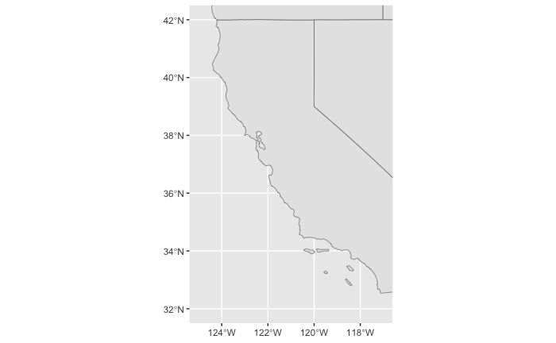

```r
# Create simple state basemap from .shp of Census bureau
# state layer from US Census bureau
# https://www.census.gov/geo/maps-data/data/cbf/cbf_state.html

states<- st_read(dsn = "./cb_2017_us_state_20m/cb_2017_us_state_20m.shp") # load the shape file with {sf}
 # note that these data are stored in our wd
states= st_transform(states, crs= 4326) # transform the data from NAD 83 to WGS 84
st_crs(states) # check that coordinates were transformed
#simple plot of Ca for ref
ggplot()+
  geom_sf(data=states)+
  coord_sf(xlim =c(-125, -117) , ylim=c(32, 42))
```

# PLOT: regridded acoustics data

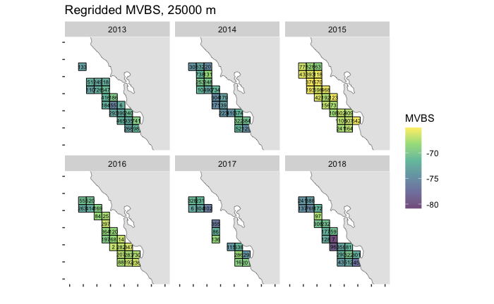

```r
{ggplot(data=acoustics_regrid)+
  geom_point(aes(x=lon, y=lat, fill=MVBS), size=4, shape=22)+
  geom_text(aes(x=lon, y=lat, label=echo_count), size=2)+ #text represents # of original cells per regrid cell
  scale_fill_viridis_c(alpha=0.7)+
  geom_sf(data=states)+ #add basemap
  coord_sf(xlim=c(-124.5, -121 ), ylim=c(36 ,39 ))+ #this is based on extent(r) raster but not UTM projection?
  #scale_x_continuous(breaks = acoustics_regrid$lon_grid_low, minor_breaks = NULL)+
  #scale_y_continuous(breaks=acoustics_regrid$lat_grid_hi, minor_breaks = NULL)+
  xlab("")+
  ylab("")+
  ggtitle(label= paste0("Regridded MVBS, ", round(dist, 2), " m"))+
  theme(axis.text.x = element_blank(),
        axis.text.y = element_blank(),
        #panel.grid = element_line(colour = "black", linetype = "solid"),
        panel.background = element_blank())+
  facet_wrap(~year)}
```

```r
#ggsave(filename=paste0("./plots/regrid/regrid_", dist, "m", "_MVBS.pdf"))
```

# PLOT regridded acoustics output with gridlines

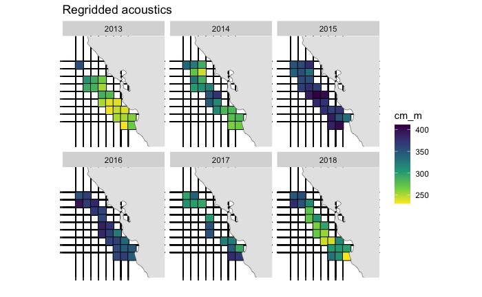

```r
# plot in ggplot (using gridlines set up for generalized raster with ALL years)
ggplot(data=acoustics_regrid)+
  geom_point(aes(x=lon, y=lat, fill=cm_m), size=4.5, shape=22)+
  scale_fill_viridis_c(direction=-1)+
  geom_sf(data=states)+ #add basemap not good one
  coord_sf(xlim=c(-124.5, -121 ), ylim=c(36 ,39 ))+ #this is based on extent(r) raster
  scale_x_continuous(breaks = acoustics_regrid$lon_grid_low, minor_breaks = NULL)+
  scale_y_continuous(breaks=acoustics_regrid$lat_grid_hi, minor_breaks = NULL)+
  xlab("")+
  ylab("")+
  ggtitle(label= "Regridded acoustics")+
  theme(axis.text.x = element_blank(),
        axis.text.y = element_blank(),
        panel.grid = element_line(colour = "black", linetype = "solid"),
        panel.background = element_blank())+
  facet_wrap(~year)

#save output
ggsave(paste0("./plots/regrid/acoustics_regrid_", "", dist, ".pdf"))
```

# Compare number of orginial cells per regrid - between years

```r
# calculate number of filled grid cells per
acoustics_regrid |>
  group_by(year) |>
  summarise(total_vertical=sum(count), total_horizontal=sum(echo_count), total_cells=n(), .groups = "drop")
```

| year | total_vertical | total_horizontal | total_cells |
| --- | --- | --- | --- |
| 2013 | 577193 | 6211 | 20 |
| 2014 | 645457 | 6973 | 21 |
| 2015 | 775940 | 8392 | 24 |
| 2016 | 489665 | 4957 | 22 |
| 2017 | 270078 | 2833 | 14 |
| 2018 | 546070 | 5463 | 21 |

NOTE: for 25km, the total number of 25 by 25km cells is pretty similar: 20, 21, 24, 22, 14, 21 (although this doesn’t include an additional filter for those 25km cells with less than 3 100m cells.)

# compare amount of data between cells?

NOTE for those cells with <10 total horizontal cells, I checked to ensure that there was >75% vertical coverage (ie if 10 horizontal cells, ~1000 vertical cells (100 per horizontal), to ensure not substantial vetical data) filter(total_horizontal<=10)

```r
# calculate number of filled grid cells per
acoustics_regrid |>
  group_by(year, cell) |>
  summarise(total_vertical=sum(count), total_horizontal=sum(echo_count), total_cells=n(), .groups="drop")
```

| year | cell | total_vertical | total_horizontal | total_cells |
| --- | --- | --- | --- | --- |
| 2013 | 1 | 12939 | 133 | 1 |
| 2013 | 2 | 4580 | 51 | 1 |
| 2013 | 3 | 23498 | 249 | 1 |
| 2013 | 4 | 1718 | 18 | 1 |
| 2013 | 5 | 10415 | 110 | 1 |
| 2013 | 6 | 69048 | 726 | 1 |
| 2013 | 7 | 59354 | 647 | 1 |
| 2013 | 8 | 39963 | 416 | 1 |
| 2013 | 9 | 18423 | 186 | 1 |
| 2013 | 10 | 17219 | 184 | 1 |

[output cut: 112 more lines]

```r
NA
NA
```

# MANUAL STEP: save output to specific grid size!

We re-gridding multiple times by changing dist= input at the moment but want to save regrid output specific to each cell size

```r
acoustics_regrid_25km= acoustics_regrid
```

Now re-run all of the code above but for the following grid sizes – 1km – 5km – 10km – 15km – 20km – 25km

# PLOT for visual reference

NOTE: use the specific acoustics_regrid_size df to plot accurately

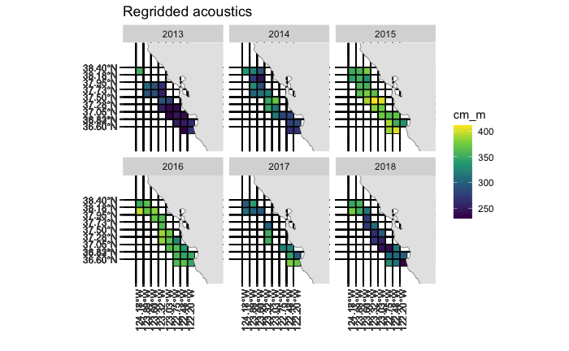

```r
# plot in ggplot (using gridlines set up for generalized raster with ALL years)
ggplot(data=acoustics_regrid)+
  geom_point(aes(x=lon, y=lat, fill=cm_m), size=3, shape=22)+
  scale_fill_viridis_c()+
  geom_sf(data=states)+ #add basemap not good one
  coord_sf(xlim=c(-124.5, -121 ), ylim=c(36 ,39 ))+ #this is based on extent(r) raster
  scale_x_continuous(breaks = round(acoustics_regrid$lon_grid_low, 2), minor_breaks = NULL)+
  scale_y_continuous(breaks= round(acoustics_regrid$lat_grid_hi, 2), minor_breaks = NULL)+
  xlab("")+
  ylab("")+
  ggtitle(label= "Regridded acoustics")+
  theme(axis.text.x = element_text(angle = 90),
        panel.grid = element_line(colour = "black", linetype = "solid"),
        panel.background = element_blank())+
  facet_wrap(~year)
```

```r
#save output
#ggsave(paste0("./plots/regrid/acoustics_regrid_", "", dist, ".pdf"))
```

# clean up objects

```r
rm(acoustics_regrid, ext, grid, i, yr, dist)
```

NOTE: leave df: r we will use this to re-grid oceanographic data from ctd in Ocean regrid.Rmd

# NEXT…..

Head to Analysis 1.Rmd (difference in biomass between years)